# multiclass-classification

### Validating your approach

**Setting aside a validation set**

```python
x_val = x_train[:1000]
partial_x_train = x_train[1000:]
y_val = y_train[:1000]
partial_y_train = y_train[1000:]
```

**Training the model**

```python
history = model.fit(partial_x_train,
                    partial_y_train,
                    epochs=20,
                    batch_size=512,
                    validation_data=(x_val, y_val))
```

[output not shown]

**Plotting the training and validation loss**

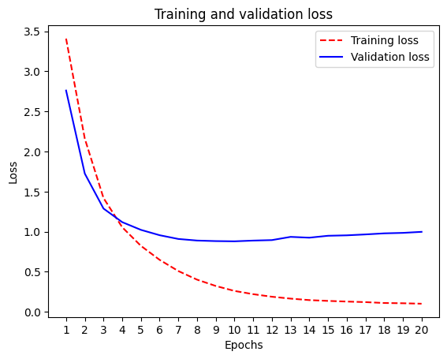

```python
import matplotlib.pyplot as plt

loss = history.history["loss"]
val_loss = history.history["val_loss"]
epochs = range(1, len(loss) + 1)
plt.plot(epochs, loss, "r--", label="Training loss")
plt.plot(epochs, val_loss, "b", label="Validation loss")
plt.title("Training and validation loss")
plt.xlabel("Epochs")
plt.xticks(epochs)
plt.ylabel("Loss")
plt.legend()
plt.show()
```

**Plotting the training and validation accuracy**

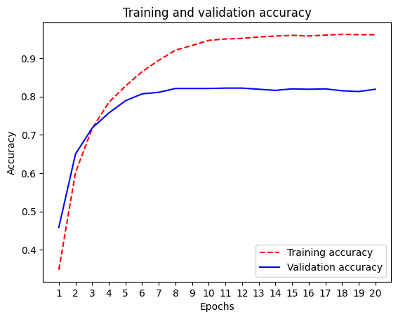

```python
plt.clf()
acc = history.history["accuracy"]
val_acc = history.history["val_accuracy"]
plt.plot(epochs, acc, "r--", label="Training accuracy")
plt.plot(epochs, val_acc, "b", label="Validation accuracy")
plt.title("Training and validation accuracy")
plt.xlabel("Epochs")
plt.xticks(epochs)
plt.ylabel("Accuracy")
plt.legend()
plt.show()
```

## Plotting the train and val top-3 accuracy

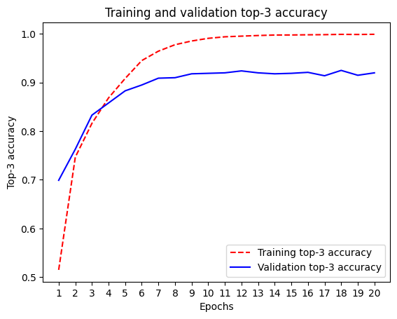

```python
plt.clf()
acc = history.history["top_3_accuracy"]
val_acc = history.history["val_top_3_accuracy"]
plt.plot(epochs, acc, "r--", label="Training top-3 accuracy")
plt.plot(epochs, val_acc, "b", label="Validation top-3 accuracy")
plt.title("Training and validation top-3 accuracy")
plt.xlabel("Epochs")
plt.xticks(epochs)
plt.ylabel("Top-3 accuracy")
plt.legend()
plt.show()
```

**Retraining a model from scratch**  
We only need to train for 9 or 10 epochs

```python
model = keras.Sequential([
  layers.Dense(64, activation="relu"),
  layers.Dense(64, activation="relu"),
  layers.Dense(46, activation="softmax")
])
model.compile(optimizer="adam",
              loss="categorical_crossentropy",
              metrics=["accuracy"])
model.fit(x_train,
          y_train,
          epochs=9,
          batch_size=512)
results = model.evaluate(x_test, y_test)
```

```
18/18 ━━━━━━━━━━━━━━━━━━━━ 2s 44ms/step - accuracy: 0.2451 - loss: 3.5673
18/18 ━━━━━━━━━━━━━━━━━━━━ 1s 42ms/step - accuracy: 0.5832 - loss: 2.2083
18/18 ━━━━━━━━━━━━━━━━━━━━ 1s 44ms/step - accuracy: 0.7132 - loss: 1.3906
18/18 ━━━━━━━━━━━━━━━━━━━━ 1s 43ms/step - accuracy: 0.7735 - loss: 1.0323
18/18 ━━━━━━━━━━━━━━━━━━━━ 1s 42ms/step - accuracy: 0.8307 - loss: 0.8138
18/18 ━━━━━━━━━━━━━━━━━━━━ 1s 42ms/step - accuracy: 0.8658 - loss: 0.6368
18/18 ━━━━━━━━━━━━━━━━━━━━ 2s 63ms/step - accuracy: 0.8964 - loss: 0.5050
18/18 ━━━━━━━━━━━━━━━━━━━━ 1s 72ms/step - accuracy: 0.9203 - loss: 0.3825
18/18 ━━━━━━━━━━━━━━━━━━━━ 2s 39ms/step - accuracy: 0.9405 - loss: 0.2958
71/71 ━━━━━━━━━━━━━━━━━━━━ 0s 3ms/step - accuracy: 0.8065 - loss: 0.9128
```

```python
results
```

```
[0.9215157628059387, 0.8000890612602234]
```

```python
# A really neat way of calculating the accuracy of a random baseline
import copy
test_labels_copy = copy.copy(test_labels)
np.random.shuffle(test_labels_copy)
hits_array = np.array(test_labels) == np.array(test_labels_copy)
hits_array.mean()
```

```
0.19145146927871773
```

### Generating predictions on new data

```python
predictions = model.predict(x_test)
```

```
71/71 ━━━━━━━━━━━━━━━━━━━━ 0s 3ms/step
```

```python
predictions[0].shape
```

```
(46,)
```

```python
np.sum(predictions[0])
```

```
1.0
```

```python
np.argmax(predictions[0])
```

```
3
```

```python
print(test_labels[0])
```

```
3
```

### A different way to handle the labels and the loss

```python
# Leave the labels as integers values
y_train = np.array(train_labels)
y_test = np.array(test_labels)
```

```python
# If the labels are integers, we should use 'sparse_categorical_crossentropy'
# Otherwise the standard 'categorical_crossentropy'
model.compile(optimizer="adam",
              loss="sparse_categorical_crossentropy",
              metrics=["accuracy"])
```

### The importance of having sufficiently large intermediate layers

**A model with an information bottleneck**

```python
model = keras.Sequential([
    layers.Dense(64, activation="relu"),
    layers.Dense(4, activation="relu"),
    layers.Dense(46, activation="softmax")
])
model.compile(optimizer="adam",
              loss="categorical_crossentropy",
              metrics=["accuracy"])
model.fit(partial_x_train,
          partial_y_train,
          epochs=20,
          batch_size=128,
          validation_data=(x_val, y_val))
```

```
63/63 ━━━━━━━━━━━━━━━━━━━━ 3s 22ms/step - accuracy: 0.0323 - loss: 3.6168 - val_accuracy: 0.2560 - val_loss: 2.7432
63/63 ━━━━━━━━━━━━━━━━━━━━ 1s 18ms/step - accuracy: 0.3989 - loss: 2.2496 - val_accuracy: 0.6340 - val_loss: 1.4761
63/63 ━━━━━━━━━━━━━━━━━━━━ 1s 17ms/step - accuracy: 0.6900 - loss: 1.2898 - val_accuracy: 0.7010 - val_loss: 1.3081
63/63 ━━━━━━━━━━━━━━━━━━━━ 1s 18ms/step - accuracy: 0.7644 - loss: 1.0298 - val_accuracy: 0.7100 - val_loss: 1.2568
63/63 ━━━━━━━━━━━━━━━━━━━━ 1s 17ms/step - accuracy: 0.7751 - loss: 0.8960 - val_accuracy: 0.7110 - val_loss: 1.2431
63/63 ━━━━━━━━━━━━━━━━━━━━ 1s 17ms/step - accuracy: 0.7905 - loss: 0.8035 - val_accuracy: 0.7190 - val_loss: 1.2327
63/63 ━━━━━━━━━━━━━━━━━━━━ 1s 17ms/step - accuracy: 0.8048 - loss: 0.7153 - val_accuracy: 0.7220 - val_loss: 1.2279
63/63 ━━━━━━━━━━━━━━━━━━━━ 2s 23ms/step - accuracy: 0.8178 - loss: 0.6495 - val_accuracy: 0.7110 - val_loss: 1.2665
63/63 ━━━━━━━━━━━━━━━━━━━━ 2s 17ms/step - accuracy: 0.8232 - loss: 0.6253 - val_accuracy: 0.7110 - val_loss: 1.2772
63/63 ━━━━━━━━━━━━━━━━━━━━ 1s 17ms/step - accuracy: 0.8369 - loss: 0.5672 - val_accuracy: 0.7100 - val_loss: 1.3072
63/63 ━━━━━━━━━━━━━━━━━━━━ 1s 17ms/step - accuracy: 0.8520 - loss: 0.5256 - val_accuracy: 0.7150 - val_loss: 1.3434
63/63 ━━━━━━━━━━━━━━━━━━━━ 1s 17ms/step - accuracy: 0.8457 - loss: 0.5231 - val_accuracy: 0.7110 - val_loss: 1.3771
63/63 ━━━━━━━━━━━━━━━━━━━━ 1s 17ms/step - accuracy: 0.8523 - loss: 0.4838 - val_accuracy: 0.7140 - val_loss: 1.4226
63/63 ━━━━━━━━━━━━━━━━━━━━ 1s 16ms/step - accuracy: 0.8595 - loss: 0.4522 - val_accuracy: 0.7180 - val_loss: 1.4109
63/63 ━━━━━━━━━━━━━━━━━━━━ 1s 17ms/step - accuracy: 0.8574 - loss: 0.4371 - val_accuracy: 0.7140 - val_loss: 1.4979
63/63 ━━━━━━━━━━━━━━━━━━━━ 1s 16ms/step - accuracy: 0.8695 - loss: 0.4084 - val_accuracy: 0.7130 - val_loss: 1.5344
63/63 ━━━━━━━━━━━━━━━━━━━━ 2s 27ms/step - accuracy: 0.8792 - loss: 0.3804 - val_accuracy: 0.7130 - val_loss: 1.5541
63/63 ━━━━━━━━━━━━━━━━━━━━ 2s 17ms/step - accuracy: 0.8871 - loss: 0.3839 - val_accuracy: 0.7170 - val_loss: 1.6075
63/63 ━━━━━━━━━━━━━━━━━━━━ 1s 17ms/step - accuracy: 0.8859 - loss: 0.3696 - val_accuracy: 0.7160 - val_loss: 1.6501
63/63 ━━━━━━━━━━━━━━━━━━━━ 1s 17ms/step - accuracy: 0.9022 - loss: 0.3325 - val_accuracy: 0.7130 - val_loss: 1.6929
```

```
<keras.src.callbacks.history.History at 0x791a02025450>
```

### Further experiments

How does the accuracy on the test set change when you:

1. change the number of neurons in the layers (such as 32, 128, etc.)?
2. increase or decrease the number of intermediate layers? (this example uses two intermediate layers before the softmax)

## def plot_loss(history)

```python
def plot_loss(history):
    loss = history.history["loss"]
    val_loss = history.history["val_loss"]
    epochs = range(1, len(loss) + 1)
    plt.plot(epochs, loss, "r--", label="Training loss")
    plt.plot(epochs, val_loss, "b", label="Validation loss")
    plt.title("Training and validation loss")
    plt.xlabel("Epochs")
    plt.xticks(epochs)
    plt.ylabel("Loss")
    plt.legend()
    plt.show()
```

```python
def plot_accuracy(history):
    plt.clf()
    acc = history.history["accuracy"]
    val_acc = history.history["val_accuracy"]
    plt.plot(epochs, acc, "r--", label="Training accuracy")
    plt.plot(epochs, val_acc, "b", label="Validation accuracy")
    plt.title("Training and validation accuracy")
    plt.xlabel("Epochs")
    plt.xticks(epochs)
    plt.ylabel("Accuracy")
    plt.legend()
    plt.show()
```

## 32 - 128 - 46

```python
model = keras.Sequential([
    layers.Dense(32, activation="relu"),
    layers.Dense(128, activation="relu"),
    layers.Dense(46, activation="softmax")
])

model.compile(optimizer="adam",
              loss="categorical_crossentropy",
              metrics=["accuracy"])

history = model.fit(partial_x_train,
          partial_y_train,
          epochs=20,
          batch_size=128,
          validation_data=(x_val, y_val))
```

```
63/63 ━━━━━━━━━━━━━━━━━━━━ 2s 16ms/step - accuracy: 0.4273 - loss: 2.9525 - val_accuracy: 0.6610 - val_loss: 1.4577
63/63 ━━━━━━━━━━━━━━━━━━━━ 1s 12ms/step - accuracy: 0.7121 - loss: 1.2628 - val_accuracy: 0.7450 - val_loss: 1.1241
63/63 ━━━━━━━━━━━━━━━━━━━━ 1s 12ms/step - accuracy: 0.8082 - loss: 0.8487 - val_accuracy: 0.7940 - val_loss: 0.9658
63/63 ━━━━━━━━━━━━━━━━━━━━ 1s 13ms/step - accuracy: 0.8813 - loss: 0.5450 - val_accuracy: 0.8020 - val_loss: 0.9091
63/63 ━━━━━━━━━━━━━━━━━━━━ 1s 14ms/step - accuracy: 0.9218 - loss: 0.3472 - val_accuracy: 0.8090 - val_loss: 0.8920
63/63 ━━━━━━━━━━━━━━━━━━━━ 1s 18ms/step - accuracy: 0.9439 - loss: 0.2477 - val_accuracy: 0.8150 - val_loss: 0.9061
63/63 ━━━━━━━━━━━━━━━━━━━━ 1s 17ms/step - accuracy: 0.9504 - loss: 0.1943 - val_accuracy: 0.8200 - val_loss: 0.9118
63/63 ━━━━━━━━━━━━━━━━━━━━ 1s 12ms/step - accuracy: 0.9582 - loss: 0.1591 - val_accuracy: 0.8130 - val_loss: 0.9459
63/63 ━━━━━━━━━━━━━━━━━━━━ 1s 12ms/step - accuracy: 0.9646 - loss: 0.1281 - val_accuracy: 0.8110 - val_loss: 0.9599
63/63 ━━━━━━━━━━━━━━━━━━━━ 1s 12ms/step - accuracy: 0.9610 - loss: 0.1376 - val_accuracy: 0.8140 - val_loss: 0.9596
63/63 ━━━━━━━━━━━━━━━━━━━━ 1s 11ms/step - accuracy: 0.9602 - loss: 0.1324 - val_accuracy: 0.8130 - val_loss: 0.9794
63/63 ━━━━━━━━━━━━━━━━━━━━ 1s 12ms/step - accuracy: 0.9605 - loss: 0.1154 - val_accuracy: 0.7970 - val_loss: 1.0415
63/63 ━━━━━━━━━━━━━━━━━━━━ 1s 11ms/step - accuracy: 0.9597 - loss: 0.1185 - val_accuracy: 0.8050 - val_loss: 1.0087
63/63 ━━━━━━━━━━━━━━━━━━━━ 1s 12ms/step - accuracy: 0.9655 - loss: 0.1031 - val_accuracy: 0.8160 - val_loss: 0.9771
63/63 ━━━━━━━━━━━━━━━━━━━━ 1s 11ms/step - accuracy: 0.9671 - loss: 0.0917 - val_accuracy: 0.8070 - val_loss: 1.0366
63/63 ━━━━━━━━━━━━━━━━━━━━ 1s 11ms/step - accuracy: 0.9615 - loss: 0.1049 - val_accuracy: 0.7960 - val_loss: 1.0613
63/63 ━━━━━━━━━━━━━━━━━━━━ 2s 17ms/step - accuracy: 0.9657 - loss: 0.0894 - val_accuracy: 0.8070 - val_loss: 0.9936
63/63 ━━━━━━━━━━━━━━━━━━━━ 1s 16ms/step - accuracy: 0.9606 - loss: 0.0985 - val_accuracy: 0.8000 - val_loss: 1.0667
63/63 ━━━━━━━━━━━━━━━━━━━━ 1s 12ms/step - accuracy: 0.9584 - loss: 0.0956 - val_accuracy: 0.8110 - val_loss: 1.0378
63/63 ━━━━━━━━━━━━━━━━━━━━ 1s 12ms/step - accuracy: 0.9641 - loss: 0.0920 - val_accuracy: 0.8050 - val_loss: 1.0242
```

```python
results = model.evaluate(x_test, y_test)
```

```
71/71 ━━━━━━━━━━━━━━━━━━━━ 0s 3ms/step - accuracy: 0.7978 - loss: 1.1421
```

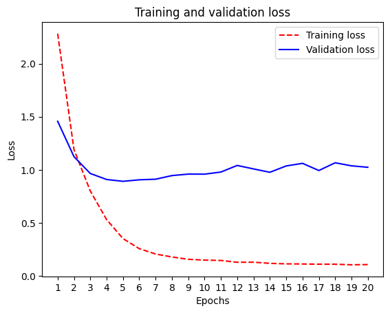

```python
plot_loss(history)
```

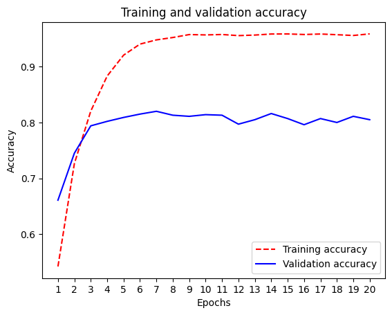

```python
plot_accuracy(history)
```

## 128-128-46

```python
model = keras.Sequential([
    layers.Dense(128, activation="relu"),
    layers.Dense(128, activation="relu"),
    layers.Dense(46, activation="softmax")
])

model.compile(optimizer="adam",
              loss="categorical_crossentropy",
              metrics=["accuracy"])

history = model.fit(partial_x_train,
          partial_y_train,
          epochs=20,
          batch_size=128,
          validation_data=(x_val, y_val))
```

```
63/63 ━━━━━━━━━━━━━━━━━━━━ 5s 44ms/step - accuracy: 0.4981 - loss: 2.5937 - val_accuracy: 0.7380 - val_loss: 1.1740
63/63 ━━━━━━━━━━━━━━━━━━━━ 4s 31ms/step - accuracy: 0.8025 - loss: 0.8943 - val_accuracy: 0.8180 - val_loss: 0.9199
63/63 ━━━━━━━━━━━━━━━━━━━━ 2s 27ms/step - accuracy: 0.9040 - loss: 0.4501 - val_accuracy: 0.8240 - val_loss: 0.8531
63/63 ━━━━━━━━━━━━━━━━━━━━ 3s 28ms/step - accuracy: 0.9418 - loss: 0.2691 - val_accuracy: 0.8240 - val_loss: 0.8691
63/63 ━━━━━━━━━━━━━━━━━━━━ 2s 33ms/step - accuracy: 0.9574 - loss: 0.1648 - val_accuracy: 0.8160 - val_loss: 0.9131
63/63 ━━━━━━━━━━━━━━━━━━━━ 3s 44ms/step - accuracy: 0.9576 - loss: 0.1533 - val_accuracy: 0.8310 - val_loss: 0.8861
63/63 ━━━━━━━━━━━━━━━━━━━━ 3s 41ms/step - accuracy: 0.9609 - loss: 0.1303 - val_accuracy: 0.8160 - val_loss: 0.9239
63/63 ━━━━━━━━━━━━━━━━━━━━ 5s 34ms/step - accuracy: 0.9626 - loss: 0.1170 - val_accuracy: 0.8250 - val_loss: 0.9584
63/63 ━━━━━━━━━━━━━━━━━━━━ 2s 32ms/step - accuracy: 0.9643 - loss: 0.1024 - val_accuracy: 0.8140 - val_loss: 0.9220
63/63 ━━━━━━━━━━━━━━━━━━━━ 3s 41ms/step - accuracy: 0.9616 - loss: 0.1121 - val_accuracy: 0.8190 - val_loss: 0.8943
63/63 ━━━━━━━━━━━━━━━━━━━━ 4s 27ms/step - accuracy: 0.9545 - loss: 0.1073 - val_accuracy: 0.8150 - val_loss: 0.9759
63/63 ━━━━━━━━━━━━━━━━━━━━ 2s 29ms/step - accuracy: 0.9658 - loss: 0.0922 - val_accuracy: 0.8190 - val_loss: 0.9473
63/63 ━━━━━━━━━━━━━━━━━━━━ 2s 28ms/step - accuracy: 0.9624 - loss: 0.0925 - val_accuracy: 0.8250 - val_loss: 0.9329
63/63 ━━━━━━━━━━━━━━━━━━━━ 2s 29ms/step - accuracy: 0.9592 - loss: 0.1029 - val_accuracy: 0.8070 - val_loss: 0.9746
63/63 ━━━━━━━━━━━━━━━━━━━━ 4s 50ms/step - accuracy: 0.9667 - loss: 0.0797 - val_accuracy: 0.8080 - val_loss: 0.9977
63/63 ━━━━━━━━━━━━━━━━━━━━ 2s 29ms/step - accuracy: 0.9617 - loss: 0.0908 - val_accuracy: 0.8100 - val_loss: 1.0005
63/63 ━━━━━━━━━━━━━━━━━━━━ 2s 28ms/step - accuracy: 0.9662 - loss: 0.0772 - val_accuracy: 0.8060 - val_loss: 1.0022
63/63 ━━━━━━━━━━━━━━━━━━━━ 2s 27ms/step - accuracy: 0.9631 - loss: 0.0887 - val_accuracy: 0.8090 - val_loss: 0.9774
63/63 ━━━━━━━━━━━━━━━━━━━━ 2s 29ms/step - accuracy: 0.9624 - loss: 0.0850 - val_accuracy: 0.8100 - val_loss: 1.0072
63/63 ━━━━━━━━━━━━━━━━━━━━ 2s 28ms/step - accuracy: 0.9652 - loss: 0.0787 - val_accuracy: 0.8170 - val_loss: 0.9904
```

```python
results = model.evaluate(x_test, y_test)
```

```
71/71 ━━━━━━━━━━━━━━━━━━━━ 1s 7ms/step - accuracy: 0.7966 - loss: 1.0975
```

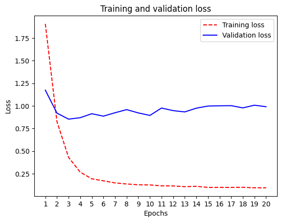

```python
plot_loss(history)
```

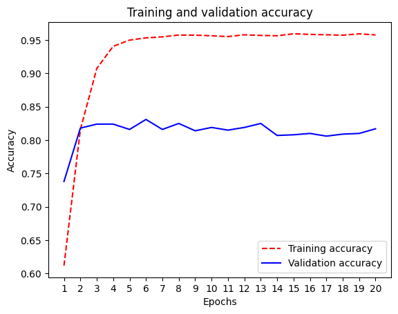

```python
plot_accuracy(history)
```

```python
model = keras.Sequential([
    layers.Dense(64, activation="relu"),
    layers.Dense(128, activation="relu"),
    layers.Dense(64, activation="relu"),
    layers.Dense(128, activation="relu"),
    layers.Dense(46, activation="softmax")
])

model.compile(optimizer="adam",
              loss="categorical_crossentropy",
              metrics=["accuracy"])

history = model.fit(partial_x_train,
          partial_y_train,
          epochs=20,
          batch_size=128,
          validation_data=(x_val, y_val))
```

```
63/63 ━━━━━━━━━━━━━━━━━━━━ 4s 28ms/step - accuracy: 0.4115 - loss: 2.7720 - val_accuracy: 0.6990 - val_loss: 1.3493
63/63 ━━━━━━━━━━━━━━━━━━━━ 2s 26ms/step - accuracy: 0.7200 - loss: 1.1788 - val_accuracy: 0.7360 - val_loss: 1.1109
63/63 ━━━━━━━━━━━━━━━━━━━━ 5s 60ms/step - accuracy: 0.8405 - loss: 0.6619 - val_accuracy: 0.7770 - val_loss: 1.0227
63/63 ━━━━━━━━━━━━━━━━━━━━ 2s 17ms/step - accuracy: 0.9065 - loss: 0.3872 - val_accuracy: 0.7970 - val_loss: 1.0087
63/63 ━━━━━━━━━━━━━━━━━━━━ 1s 19ms/step - accuracy: 0.9401 - loss: 0.2578 - val_accuracy: 0.7920 - val_loss: 1.0938
63/63 ━━━━━━━━━━━━━━━━━━━━ 1s 18ms/step - accuracy: 0.9507 - loss: 0.1955 - val_accuracy: 0.7870 - val_loss: 1.0983
63/63 ━━━━━━━━━━━━━━━━━━━━ 1s 18ms/step - accuracy: 0.9542 - loss: 0.1564 - val_accuracy: 0.7930 - val_loss: 1.1041
63/63 ━━━━━━━━━━━━━━━━━━━━ 1s 19ms/step - accuracy: 0.9599 - loss: 0.1266 - val_accuracy: 0.8060 - val_loss: 1.0789
63/63 ━━━━━━━━━━━━━━━━━━━━ 1s 19ms/step - accuracy: 0.9603 - loss: 0.1220 - val_accuracy: 0.7850 - val_loss: 1.1657
63/63 ━━━━━━━━━━━━━━━━━━━━ 1s 20ms/step - accuracy: 0.9657 - loss: 0.1039 - val_accuracy: 0.7910 - val_loss: 1.1931
63/63 ━━━━━━━━━━━━━━━━━━━━ 2s 30ms/step - accuracy: 0.9656 - loss: 0.1023 - val_accuracy: 0.8020 - val_loss: 1.1305
63/63 ━━━━━━━━━━━━━━━━━━━━ 2s 20ms/step - accuracy: 0.9627 - loss: 0.1003 - val_accuracy: 0.7950 - val_loss: 1.1619
63/63 ━━━━━━━━━━━━━━━━━━━━ 1s 19ms/step - accuracy: 0.9628 - loss: 0.0892 - val_accuracy: 0.8050 - val_loss: 1.1513
63/63 ━━━━━━━━━━━━━━━━━━━━ 2s 24ms/step - accuracy: 0.9600 - loss: 0.0904 - val_accuracy: 0.7880 - val_loss: 1.1853
63/63 ━━━━━━━━━━━━━━━━━━━━ 3s 30ms/step - accuracy: 0.9624 - loss: 0.0907 - val_accuracy: 0.7980 - val_loss: 1.1853
63/63 ━━━━━━━━━━━━━━━━━━━━ 1s 21ms/step - accuracy: 0.9638 - loss: 0.0843 - val_accuracy: 0.8060 - val_loss: 1.1569
63/63 ━━━━━━━━━━━━━━━━━━━━ 2s 32ms/step - accuracy: 0.9631 - loss: 0.0806 - val_accuracy: 0.8030 - val_loss: 1.2034
63/63 ━━━━━━━━━━━━━━━━━━━━ 2s 35ms/step - accuracy: 0.9675 - loss: 0.0706 - val_accuracy: 0.7910 - val_loss: 1.2569
63/63 ━━━━━━━━━━━━━━━━━━━━ 1s 17ms/step - accuracy: 0.9631 - loss: 0.0771 - val_accuracy: 0.7970 - val_loss: 1.2251
63/63 ━━━━━━━━━━━━━━━━━━━━ 1s 18ms/step - accuracy: 0.9605 - loss: 0.0800 - val_accuracy: 0.8050 - val_loss: 1.2658
```

```python
results = model.evaluate(x_test, y_test)
```

```
71/71 ━━━━━━━━━━━━━━━━━━━━ 0s 4ms/step - accuracy: 0.7866 - loss: 1.5195
```

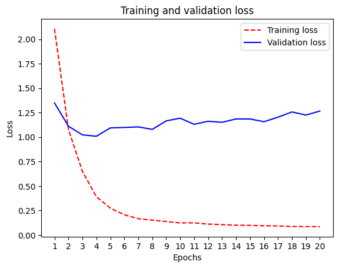

```python
plot_loss(history)
```

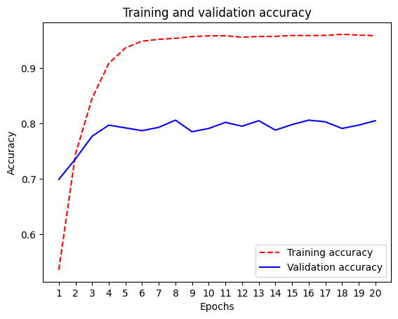

```python
plot_accuracy(history)
```

```python
model = keras.Sequential([
    layers.Dense(128, activation="relu"),
    layers.Dense(128, activation="relu"),
    layers.Dense(128, activation="relu"),
    layers.Dense(128, activation="relu"),
    layers.Dense(46, activation="softmax")
])

model.compile(optimizer="adam",
              loss="categorical_crossentropy",
              metrics=["accuracy"])

history = model.fit(partial_x_train,
          partial_y_train,
          epochs=20,
          batch_size=128,
          validation_data=(x_val, y_val))
```

```
63/63 ━━━━━━━━━━━━━━━━━━━━ 4s 35ms/step - accuracy: 0.4701 - loss: 2.6749 - val_accuracy: 0.6910 - val_loss: 1.2866
63/63 ━━━━━━━━━━━━━━━━━━━━ 2s 32ms/step - accuracy: 0.7607 - loss: 0.9871 - val_accuracy: 0.7520 - val_loss: 1.0526
63/63 ━━━━━━━━━━━━━━━━━━━━ 3s 42ms/step - accuracy: 0.8572 - loss: 0.5709 - val_accuracy: 0.7890 - val_loss: 1.0224
63/63 ━━━━━━━━━━━━━━━━━━━━ 2s 30ms/step - accuracy: 0.9314 - loss: 0.2995 - val_accuracy: 0.8040 - val_loss: 1.0471
63/63 ━━━━━━━━━━━━━━━━━━━━ 2s 30ms/step - accuracy: 0.9514 - loss: 0.1986 - val_accuracy: 0.7910 - val_loss: 1.0634
63/63 ━━━━━━━━━━━━━━━━━━━━ 2s 29ms/step - accuracy: 0.9573 - loss: 0.1457 - val_accuracy: 0.8070 - val_loss: 1.1001
63/63 ━━━━━━━━━━━━━━━━━━━━ 3s 29ms/step - accuracy: 0.9615 - loss: 0.1235 - val_accuracy: 0.7880 - val_loss: 1.1041
63/63 ━━━━━━━━━━━━━━━━━━━━ 2s 34ms/step - accuracy: 0.9594 - loss: 0.1138 - val_accuracy: 0.8040 - val_loss: 1.0341
63/63 ━━━━━━━━━━━━━━━━━━━━ 3s 35ms/step - accuracy: 0.9640 - loss: 0.0976 - val_accuracy: 0.8000 - val_loss: 1.0765
63/63 ━━━━━━━━━━━━━━━━━━━━ 2s 30ms/step - accuracy: 0.9639 - loss: 0.0961 - val_accuracy: 0.7940 - val_loss: 1.1424
63/63 ━━━━━━━━━━━━━━━━━━━━ 2s 29ms/step - accuracy: 0.9612 - loss: 0.0912 - val_accuracy: 0.8040 - val_loss: 1.1375
63/63 ━━━━━━━━━━━━━━━━━━━━ 3s 29ms/step - accuracy: 0.9661 - loss: 0.0810 - val_accuracy: 0.7880 - val_loss: 1.2549
63/63 ━━━━━━━━━━━━━━━━━━━━ 2s 30ms/step - accuracy: 0.9582 - loss: 0.1009 - val_accuracy: 0.8070 - val_loss: 1.1499
63/63 ━━━━━━━━━━━━━━━━━━━━ 3s 45ms/step - accuracy: 0.9673 - loss: 0.0705 - val_accuracy: 0.8020 - val_loss: 1.1586
63/63 ━━━━━━━━━━━━━━━━━━━━ 2s 30ms/step - accuracy: 0.9673 - loss: 0.0740 - val_accuracy: 0.8060 - val_loss: 1.2472
63/63 ━━━━━━━━━━━━━━━━━━━━ 3s 29ms/step - accuracy: 0.9668 - loss: 0.0716 - val_accuracy: 0.7940 - val_loss: 1.2666
63/63 ━━━━━━━━━━━━━━━━━━━━ 3s 29ms/step - accuracy: 0.9687 - loss: 0.0682 - val_accuracy: 0.7900 - val_loss: 1.3009
63/63 ━━━━━━━━━━━━━━━━━━━━ 3s 30ms/step - accuracy: 0.9661 - loss: 0.0747 - val_accuracy: 0.7970 - val_loss: 1.2502
63/63 ━━━━━━━━━━━━━━━━━━━━ 3s 41ms/step - accuracy: 0.9668 - loss: 0.0670 - val_accuracy: 0.8040 - val_loss: 1.2827
63/63 ━━━━━━━━━━━━━━━━━━━━ 2s 29ms/step - accuracy: 0.9642 - loss: 0.0736 - val_accuracy: 0.7900 - val_loss: 1.3247
```

```python
results = model.evaluate(x_test, y_test)
```

```
71/71 ━━━━━━━━━━━━━━━━━━━━ 0s 3ms/step - accuracy: 0.7830 - loss: 1.5007
```

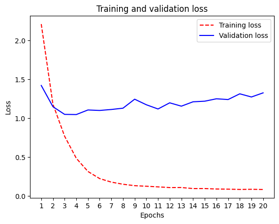

```python
plot_loss(history)
```

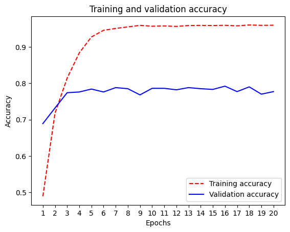

```python
plot_accuracy(history)
```